# Implementing Instrumental Variable Regression in R

Recitation Period 7

Alexander Dean

Vanderbilt University

2025-02-27

# Introductory Spiel

## What We Will Cover Today

1. A quick introduction to what IV regression is:
   - What is an instrument?
   - Assumptions needed to recover LATE
2. Implementing an instrumental variable regression in R with the AER package

## The Limits of Selection-on-observales:

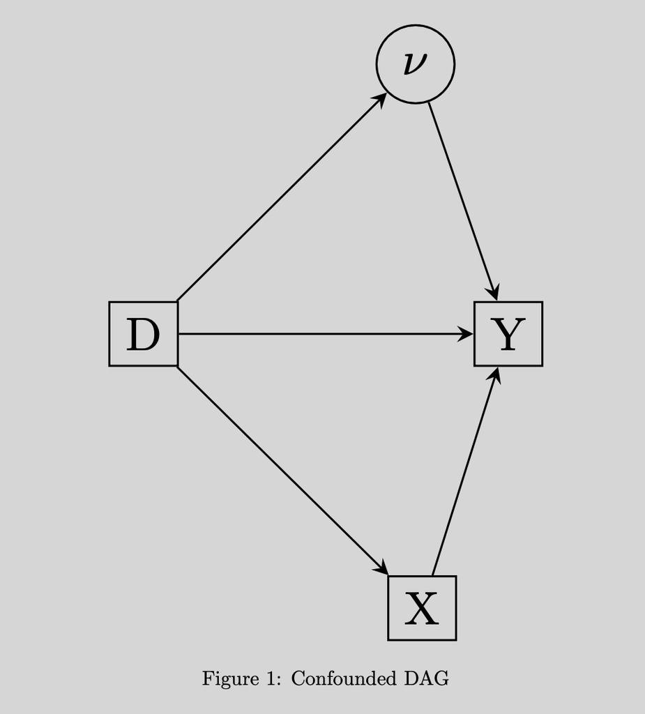

Figure 1

## Introducing Instrumental Variables

1. Under certain assumptions, we can still causally estimate observational data even when we are unable to use a selection-on-observables strategy!
2. One such approach is called an **instrumental variables** identification strategy

## (Brief) Overview of Necessities for IV

1. Some variable $Z_{i}$ (instrument) is correlated with $D_{i}$ (first stage assumption)
2. $Z_{i}$ is uncorrelated with $X_{i}$ and $\nu_{i}$ (independence assumption)
3. $Z_{i}$ **ONLY** influences $Y_{i}$ through $D_{i}$ (exclusion restriction assumption)

## Visualizing IVs in a DAG

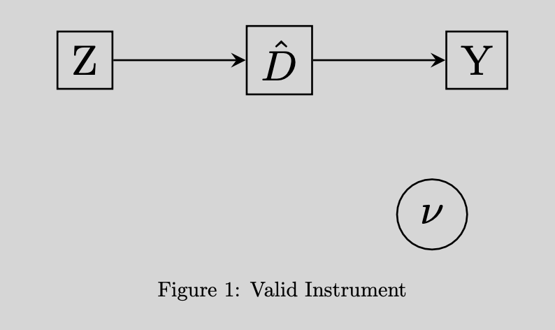

Figure 2

## Visualizing (Violated) IVs in a DAG

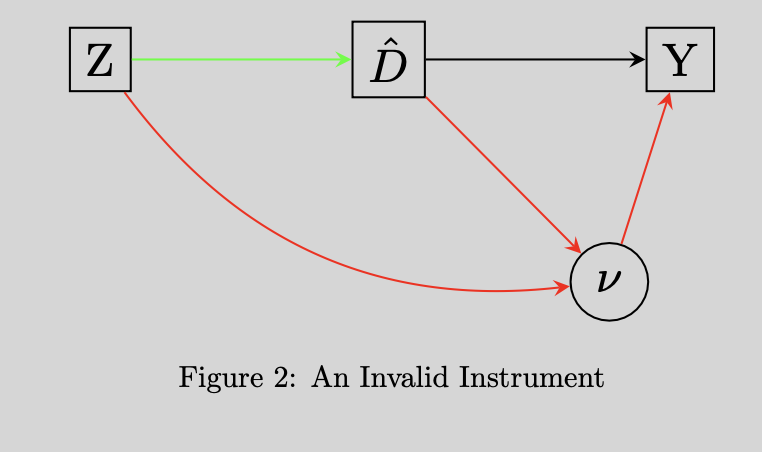

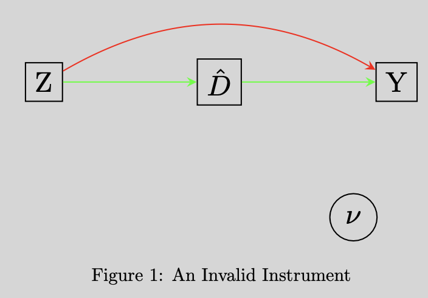

## Going From DAG to Data

1. IV typically relies on a two-stage regression
- Regress the first stage with Z on D to obtain $\hat{D}$
- Then regress $\hat{D}$ on Y
- You now have the local average treatment effect (The ATE among compliers)
- This is a **VERY** rough overview, we will learn about IVs more formally in class

# Implementing IVs in R

## The AER Package and Nunn & Wantchekon (2011)

Let’s move to [iv_practicum.R](https://github.com/gerasy1987/PSCI8357/tree/main/recitation_material/week_7)

Alexander Dean (Vanderbilt University)